# Lab5_inferential_statistics

2023-01-31

```r
suppressWarnings(library(tidyverse))
```

## Статистика вывода

Построение выводов о свойствах популяции (генеральной совокупности) на основе анализа случайных выборок.

0. Гипотеза исследования
1. Нулевая и альтернативная гипотеза
2. Подсчет статистики по выборке
3. Расчет p-value
4. Принятие решения

**1. Формулирование нулевой и альтернативной гипотезы.**

Пример: Средняя длина предложений у носителей и изучающих язык.

$$H_1: \mu_1 \ne \mu_2$$

Нулевая гипотеза:

$$H_0: \mu_1 = \mu_2$$

Гипотеза $H_1$ называется также альтернативной. NB $H_1$ и $H_0$ касаются популяции, а не конкретной выборки.

Тестирование нулевой гипотезы предполагает подсчет какой-то статистики, а потом вычисление того, какова вероятность получить такой или более радикальный результат при условии, что верна нулевая гипотеза.

Другие варианты альтернативной и нулевой гипотезы
$$H_1: \mu_1 > \mu_2$$
$$H_0: \mu_1 = \mu_2$$
или:

$$H_1: \mu_ < \mu_2$$
$$H_0: \mu_1 = \mu_2$$
Начнем с еще более простого случая, когда у нас есть только одна группа:

$$H_1: \mu \ne 100$$
$$H_0: \mu = 100$$

**2. Подсчет тестовой статистики по выборке**

Задача: сравнить полученное значение статистики в тесте с другими *возможными* значениями, которые мы могли бы получить, если бы наша нулевая гипотеза была верна.

Пример: z-статистика на основе z-распределения. Если мы знаем среднее и стандартное отклонение в генеральной совокупности, то можем посчитать $z$-статистику по формуле:

$$z = \frac{\overline{x} - \mu} {\sigma /
\sqrt{N}}$$
$z$-статистика — это выборочное среднее, из которого вычтено среднее в генеральной совокупности согласно нашей гипотезе. Получившуюся разницу мы делим на стандартную ошибку.

```r
set.seed(42)
samp <- rnorm(100, mean = 100, sd = 15)
m <- mean(samp)
sem <- 15/sqrt(length(samp))
z <- (m - 100)/sem
z
```

```
## [1] 0.3251482
```

**3. Расчет p-value**

p-value – это вероятность получить такую и более отклоняющуюся тестовую статистику при условии, что $H_0$ верна.

Вернемся к идее выборочных распределений, только теперь уже не среднего, а $z$-статистики. Благодаря тому, что мы вычли среднее и поделили на стандартное отклонение, среднее этого нормального распределения будет равно 0, а стандартное отклонение – 1.

Благодаря ЦПТ, даже если распределение в генеральной совокупности несколько отличается от нормального, а выборка достаточно большая, то выборочное распределение $z$-статистик при верности нулевой гипотезы будет (примерно) нормальным.

Соотнесем нашу $z$-статистику с теоретическим выборочным распределением $z$-статистик. Какова вероятность получить такой же или более радикально отличающийся результат при допущении верности нулевой гипотезы, т.е. какова p-value?

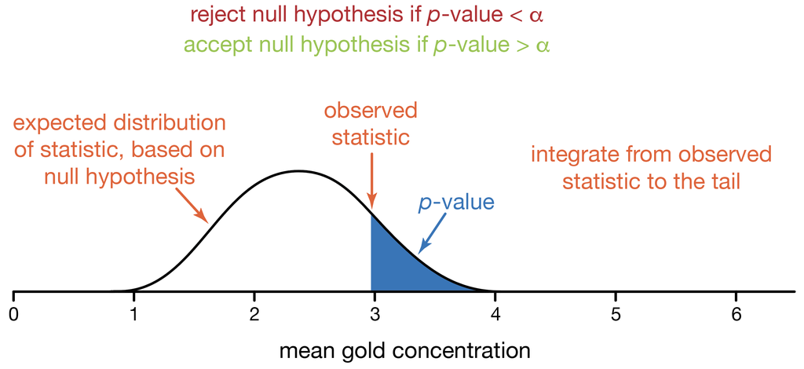

Если $z$-статистика отрицательная, то считаем от минус бесконечности до $z$-статистики.

Другой способ - воспользуемся функцией накопленной плотности распределения `pnorm()`:

```r
pnorm(z)
```

```
## [1] 0.6274655
```

`pnorm()` считает от минус бесконечности до заданного числа, поэтому для z>0 вычтем площадь из единицы.

```r
1 - pnorm(z)
```

```
## [1] 0.3725345
```

```r
# or
pnorm(z, lower.tail=FALSE)
```

```
## [1] 0.3725345
```

Теперь это число нужно умножить на 2, потому что мы заранее не знаем, в какую сторону будет отклоняться среднее по нашей выборке.

Это означает, что $H_1$ включает в себя как случаи, когда среднее отклоняется в большую сторону, так и случаи когда среднее отклоняется в меньшую сторону.

```r
p <- (1 - pnorm(z))*2
p
```

```
## [1] 0.7450689
```

Это число и есть **p-value** — вероятность получения такого же и более экстремального значения тестовой статистики при условии, что нулевая гипотеза верна.

**4. Принятие решения о гипотезах**

Насколько маленьким должен быть *p-value*, чтобы отклонить нулевую гипотезу? **Критическое значение *p-value*, при котором отклоняют нулевую гипотезу, называется уровнем** $\alpha$. Это максимальный уровень ошибки, который мы допускаем в исследовании.

Стандартный уровень $\alpha$ в научной литературе 0.05 (5%). Но это условность, и есть рекомендации считать $\alpha=0.01$ в отдельных отраслях и при определенных дизайнах исследования.

| Принятое решение Реальность | $H_0$ верна | $H_1$ верна |
| --- | --- | --- |
| Не отклоняем $H_0$ | Верный пропуск | Ошибка 2 рода (type II error) |
| Отклоняем $H_0$ | Ошибка 1 рода (type I error) | Верное попадание |

Если $H_0$ на самом деле верна, а мы ее отвергли и приняли $H_1$, то это **ошибка первого рода** (*type I error*). Вероятность этой ошибки и есть наше критическое значение $\alpha$. Однако есть вероятность ошибиться и в другую сторону, т.е. ошибочно не отклонить $H_0$ — это **ошибка второго рода** (*type II error*), эта вероятность обозначается буквой $\beta$.

# t-тест Уильяма Госсета

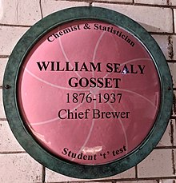

## Одновыборочный t-тест

Мы научились делать z-тест. Но на практике это обычно не так, так как мы оцениваем стандартное отклонение в генеральной совокупности на основе стандартного отклонения по выборке. Эта тестовая статистика уже не распределена нормально, а распределена согласно t-распределению. Наша статистика - t-статистика.

$$t = \frac{\overline{x} - \mu} {s_x /
\sqrt{N}}$$

Форма этого распределения очень похожа на форму нормального распределения, но имеет более тяжелые “хвосты” распределения. При этом эта форма зависит от размера выборки: чем больше выборка, тем ближе распределение к нормальному. Этот параметр распределения называется **степенями свободы** *(degrees of freedom)* и вычисляется как $N - 1$, где $N$ - это размер выборки.

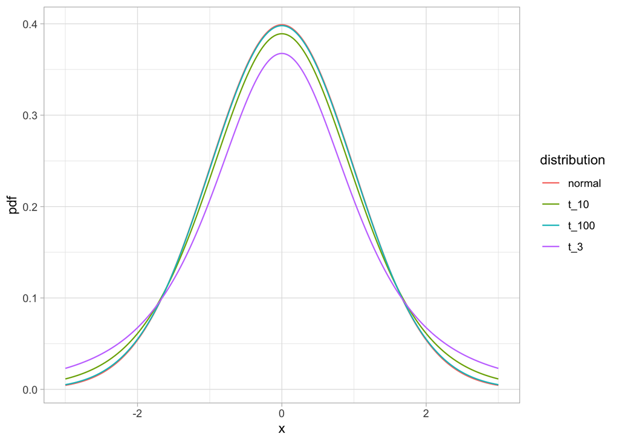

Чем больше выборка (и количество степеней свободы, соответственно), тем ближе t-распределение к стандартному нормальному распределению. При 100 степенях свободы они уже почти не различимы! Поэтому на больших выборках разница между t-тестом и z-тестом будет минимальна, тогда как на маленьких выборках разница может быть значительной.

Посчитаем t-статистику:

```r
set.seed(42)
samp <- rnorm(100, 100, 15)
m <- mean(samp)
sem <- sd(samp)/sqrt(length(samp))
t <- (m - 100)/sem
t
```

```
## [1] 0.3122351
```

Сравним с z-статистикой:

```r
(m - 100) / (15/sqrt(100))
```

```
## [1] 0.3251482
```

Как видите, расчет довольно схожий, разница только в том, откуда мы берем стандартное отклонение. Для z-статистики у нас был заранее известный параметр генеральной совокупности (что обычно не так), для t-статистики мы оценивали стандартное отклонение по выборке.

Давайте теперь посчитаем p-value. Мы будем пользоваться не функцией `pnorm()`, а функцией `pt()`, а в качестве параметра распределения указать количество степеней свобод в `df =`

```r
pt(t, df = length(samp) - 1)
```

```
## [1] 0.6222407
```

Функция `pt()` считает от минус бесконечности до $t$, а нам нужно от $t$ до плюс бесконечности, потому что $t$ больше 0:

```r
1 - pt(t, df = length(samp) - 1)
```

```
## [1] 0.3777593
```

И не забываем умножать на 2, если мы хотим сделать двусторонний тест.

```r
(1 - pt(t, df = length(samp) - 1))*2
```

```
## [1] 0.7555186
```

В отличие от z-теста, t-тест есть в базовом R.

```r
t.test(samp, mu = 100)
```

```
##
##  One Sample t-test
##
## data:  samp
## t = 0.31224, df = 99, p-value = 0.7555
## alternative hypothesis: true mean is not equal to 100
## 95 percent confidence interval:
##   97.38831 103.58714
## sample estimates:
## mean of x
##  100.4877
```

```r
0.3122351
```

```
## [1] 0.3122351
```

Здесь можно увидеть выборочное среднее как оценку среднего в генеральной совокупности, 95% доверительный интервал для оценки среднего в генеральной совокупности, t-статистику, степени свобод и p-value.

### Упражнение 1

Возьмем датасет durationsOnt (Pluymaekers et al., 2005) из учебника Baayen 2008. Он содержит измерения длительности произнесения префикса ont- в устном корпусе нидерландского языка. Предположим, что предыдущие исследования показали, что средняя длительность переменной DurationPrefixNasal (длительность произнесения сегмента -n- в секундах) составляет 0.056. Верно ли, что среднее значение DurationPrefixNasal, полученное в данном эксперименте, значимо отличается от 0.056?

```r
# install.packages("languageR")
library(languageR)
data(durationsOnt)
```

1. Получите описательные статистики по переменной DurationPrefixNasal, постройте гистограмму.
2. Сформулируйте нулевую и альтернативную гипотезу.

```
H0:
H1:
```

3. Проведите одновыборочный t-test, для интерпретации используйте критическое значение статистической значимости в 5%.
4. Можем ли мы отвергнуть нулевую гипотезу? Сформулируйте ваши выводы о статистической значимости результатов.

Пример: При проверке гипотезы о равенстве среднего в выборке 0,53 мы сформулировали нулевую и двустороннюю альтернативную гипотезу таким образом:

$H_0: mean(x) = 0.53$ $H_1: mean(x) \ne 0.53$

И записали выводы так:

Для проверки гипотезы о равенстве средней длительности назального сегмента 0,53 был проведен одновыборочный тест Стьюдента. Тест показал, что мы можем отвергнуть нулевую гипотезу (t = -226.73, df = 101, p-value < 2.2e-16). Тем самым, среднее значение DurationPrefixNasal в выборке (0,05) статистически значимо отличается от 0,53.

### Односторонние альтернативные гипотезы (больше-меньше)

$H1: \mu1 > \mu_0$

```r
my_sample <- c(80, 90, 100, 100, 130)
mu0 <- 125
mean(my_sample)
```

```
## [1] 100
```

```r
t.test(my_sample, mu = mu0, alternative = 'less')
```

```
##
##  One Sample t-test
##
## data:  my_sample
## t = -2.9881, df = 4, p-value = 0.02021
## alternative hypothesis: true mean is less than 125
## 95 percent confidence interval:
##      -Inf 117.8363
## sample estimates:
## mean of x
##       100
```

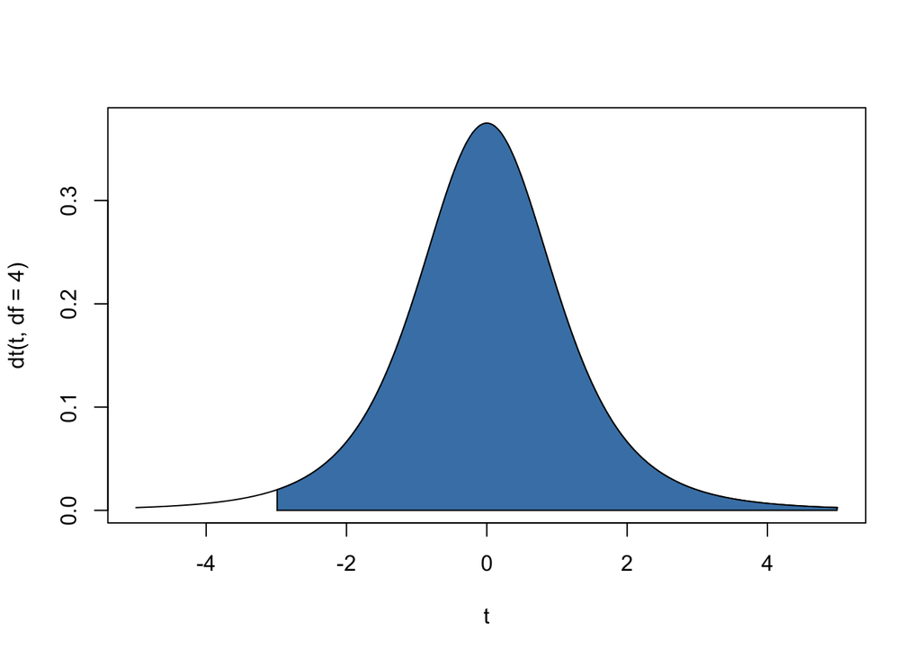

```r
x <- seq(-2.9881, 5, 0.01)
curve(dt(t, df=4), from = -5, to=5, xname = 't')
# add shading
polygon(c(x[1], x, x[length(x)]),
        c(0, dt(x, df=4), 0), col="steelblue")
```

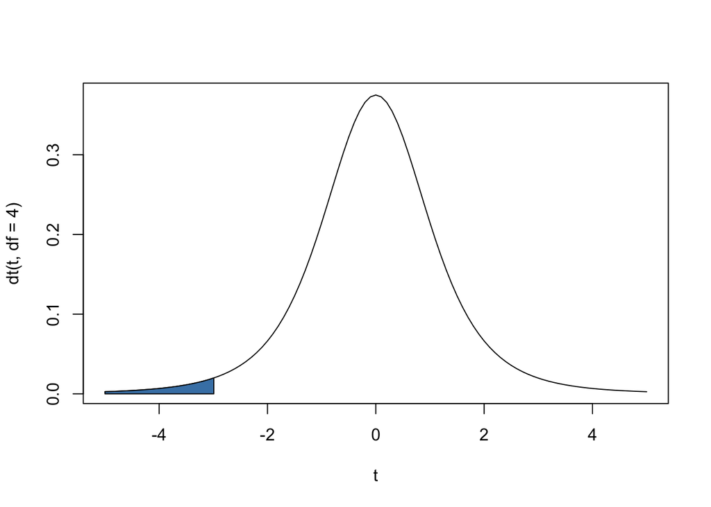

```r
x <- seq(-5, -2.9881, 0.01)
curve(dt(t, df=4), from = -5, to=5, xname='t')

# add shading
polygon(c(x[1], x, x[length(x)]),
        c(0, dt(x, df=4), 0), col="steelblue")
```

Проведем односторонние t-тесты для переменной DurationPrefixNasal из упражнения. В этот раз будем сравнивать со значением 0.054.

```r
t.test(durationsOnt$DurationPrefixNasal, mu = 0.054)
```

```
##
##  One Sample t-test
##
## data:  durationsOnt$DurationPrefixNasal
## t = -1.976, df = 101, p-value = 0.05089
## alternative hypothesis: true mean is not equal to 0.054
## 95 percent confidence interval:
##  0.04561370 0.05401646
## sample estimates:
##  mean of x
## 0.04981508
```

```r
# H1: mean(DurationPrefixNasal) != 0.056
# p-value 0.05089, не можем отвергнуть H0

t.test(durationsOnt$DurationPrefixNasal, mu = 0.054, alternative = "less")
```

```
##
##  One Sample t-test
##
## data:  durationsOnt$DurationPrefixNasal
## t = -1.976, df = 101, p-value = 0.02544
## alternative hypothesis: true mean is less than 0.054
## 95 percent confidence interval:
##        -Inf 0.05333099
## sample estimates:
##  mean of x
## 0.04981508
```

```r
# H1: mean(DurationPrefixNasal) < 0.056
# p-value 0.02544 (в два раза меньше!), можем отвергнуть H0

t.test(durationsOnt$DurationPrefixNasal, mu = 0.054, alternative = "greater")
```

```
##
##  One Sample t-test
##
## data:  durationsOnt$DurationPrefixNasal
## t = -1.976, df = 101, p-value = 0.9746
## alternative hypothesis: true mean is greater than 0.054
## 95 percent confidence interval:
##  0.04629917        Inf
## sample estimates:
##  mean of x
## 0.04981508
```

```r
# H1: mean(DurationPrefixNasal) > 0.056
# p-value 0.9746, не можем отвергнуть H0
```

## Двухвыборочный t-тест

Тест на сравнение средних двух выборок.
$$H_0: \mu_1 = \mu_2$$
$$H_1: \mu_1 \ne \mu_2$$

## Зависимый и независимый t-test.

Зависимый - тест с повторными измерениями (или другими зависимостями, внутрииндивидуальный дизайн исследования). Независимый - нельзя напрямую соотнести значения в двух выборках друг с другом, более того, размер двух выборок может быть разным (межиндивидуальный дизайн исследования)

| Внутрииндивидуальный план | Межиндивидуальный план |
| --- | --- |
| Зависимый t-тест | Независимый t-тест |

## Двухвыборочный зависимый t-тест

Двухвыборочный зависимый t-тест — это то же самое, что и одновыборочный t-тест, только для разницы между связанными значениями. Поскольку наша нулевая гипотеза звучит, что средние должны быть равны,

$$H_0: \mu_1 = \mu_2$$

то при верности нулевой гипотезы
$$\mu_1 -
\mu_2 = 0$$
.

Тогда вместо $x$ подставим $d$ — разницу (вектор разниц) между парами значений. Получаем вот что:

$$t = \frac{\overline{x} - \mu} {s_x /
\sqrt{N}} = \frac{\overline{d} - (\mu_1 - \mu_2)} {s_d / \sqrt{N}} =
\frac{\overline{d} - 0} {s_d / \sqrt{N}} = \frac{\overline{d}} {s_d /
\sqrt{N}}$$

Мы будем использовать [данные с курса по статистике Университета Шеффилда про эффективность диет](https://www.sheffield.ac.uk/polopoly_fs/1.570199!/file/stcp-Rdataset-Diet.csv). Возьмем данные по диете номер 1 и посмотрим, действительно ли она помогает сбросить вес.

```r
library(tidyverse)
diet <- readr::read_csv("https://raw.githubusercontent.com/Pozdniakov/tidy_stats/master/data/stcp-Rdataset-Diet.csv")
diet1 <- diet |>
  filter(Diet == 1) |>
  droplevels()
```

Чтобы провести двухвыборочный зависимый t-тест, передадим функции `t.test` два вектора одинаковой (!) длины. Это удобно в случае широкого формата данных.

```r
t.test(diet1$pre.weight, diet1$weight6weeks, paired = TRUE)
```

```
##
##  Paired t-test
##
## data:  diet1$pre.weight and diet1$weight6weeks
## t = 7.2168, df = 23, p-value = 2.397e-07
## alternative hypothesis: true mean difference is not equal to 0
## 95 percent confidence interval:
##  2.354069 4.245931
## sample estimates:
## mean difference
##             3.3
```

Мы указали `paired = TRUE` , чтобы обозначить использование именно зависимого (т.е. парного) t-теста.

| Внутрииндивидуальный план | Межиндивидуальный план |
| --- | --- |
| Зависимый t-тест | Независимый t-тест |
| `t.test(..., paired = TRUE)` | `t.test(..., paired = FALSE)` |

При длинном формате данных функция `t.test()` для зависимого теста будет выдавать ошибку, поскольку она не умеет сопоставлять данные при `paired = TRUE`. Но в независимом тесте (о котором речь ниже) это очень удобный формат.

```r
diet1_long <- diet1 |>
  pivot_longer(
  cols = c(pre.weight, weight6weeks),
  names_to = "when",
  values_to = "weight"
  )

#t.test(weight ~ when, data = diet2_long, paired = TRUE)
```

## Двухвыборочный независимый t-тест

В случае независимого t-теста формула отличается. Однако гипотеза остается такой же и логика примерна та же.

У двух выборок могут различаться стандартные отклонения, поэтому для подсчет стандартной ошибки разницы средних для независимых выборок нужно сначала посчитать **объединенное стандартное отклонение (pooled standard deviation)**:

$$s^2_{pool} = \frac {(n_1-1)s^2_1 +
(n_2-1)s^2_2} {(n_1 - 1) + (n_2 -1)}$$

Тогда стандартная ошибка разницы средних считается следующим образом:

$$se_{m_1 - m_2} = \sqrt {(s^2_{pool})
(\frac {1} {n_1} + \frac {1}{n_2} )}$$

Выглядит сложно, но по своей сути это что-то вроде усредненного стандартного отклонения (с учетом размеров выборок). Ну а t-статистика затем считается просто:

$$t = \frac {(m_1 - m_2) - (\mu_1 -
\mu_2)} {se_{m_1 - m_2}} = \frac {(m_1 - m_2) - 0} {se_{m_1 - m_2}} =
\frac {m_1 - m_2} {se_{m_1 - m_2}}$$

Давайте теперь опробуем независимый t-тест для сравнения веса испытуемых двух групп после диеты. Мы снова воспользуемся функцией `t.test()`, но теперь уже поставим `paired = FALSE`:

```r
diet12 <- diet |>
  filter(Diet %in% 1:2)
t.test(weight6weeks ~ Diet, data = diet12)
```

```
##
##  Welch Two Sample t-test
##
## data:  weight6weeks by Diet
## t = 0.5711, df = 48.724, p-value = 0.5706
## alternative hypothesis: true difference in means between group 1 and group 2 is not equal to 0
## 95 percent confidence interval:
##  -3.753268  6.732897
## sample estimates:
## mean in group 1 mean in group 2
##        69.57500        68.08519
```

Степени свободы в результатах теста дробные! Дело в том, что мы провели не совсем “настоящий” t-тест, а его очень близкую альтернативу под названием **тест Уэлча** *(Welch test)*, который иногда называют **поправкой Уэлча** к t-тесту. Эта поправка позволяет тесту лучше справляться с выборками с разной дисперсией. Даже если у нас нет проблем с разной дисперсией, то от поправки Уэлча хуже не будет, поэтому это вариант по умолчанию в R.

Но если его хочется отключить, то нужно поставить `var.equal = TRUE`.

```r
t.test(weight6weeks ~ Diet, data = diet12, var.equal = TRUE)
```

```
##
##  Two Sample t-test
##
## data:  weight6weeks by Diet
## t = 0.5645, df = 49, p-value = 0.575
## alternative hypothesis: true difference in means between group 1 and group 2 is not equal to 0
## 95 percent confidence interval:
##  -3.813769  6.793399
## sample estimates:
## mean in group 1 mean in group 2
##        69.57500        68.08519
```

### Допущения t-теста

Чтобы подсчет *p-value* был корректным, некоторые допущения должны быть выполнены.

1. **Непрерывные** данные, **Нормальное распределение** Если размер выборки больше 28 (30, 50), то обычно игнорируют.
2. Для двувыборочного независимого t-теста выборки должны быть взяты из распределения **с одинаковыми дисперсиями**. Однако это не так критично с применением поправки Уэлча.
3. **Независимость значений (или пар)** в выборке. Типичным примером нарушения независимости является случай, когда t-тест применяется на неусредненных (например, по испытуемому) значениях. Еще один пример нарушения независимости — использование одного наблюдения несколько раз или использование одного и того же испытуемого несколько раз. Определить независимость можно следующим мысленным экспериментом: могу ли я хоть как-нибудь предсказать следующее значение в выборке? Например, в случае с несколькими значениями от одного испытуемого я могу ориентироваться на его предыдущие результаты и предсказать последующие результаты лучше, чем на основе простого среднего по всем остальным значениям. Это значит, что допущение о независимости нарушено.

Нормальность распределения можно оценивать количественно с помощью теста Шапиро-Уилка:

```r
shapiro.test(samp)
```

```
##
##  Shapiro-Wilk normality test
##
## data:  samp
## W = 0.98122, p-value = 0.1654
```

```r
# H0: data is normal
# p-value < 0.05 => отвергаем H0 (распределение данных значительно отклоняется от нормального)
```

или оценивать данные визуально с помощью гистограммы или Q-Q plot.

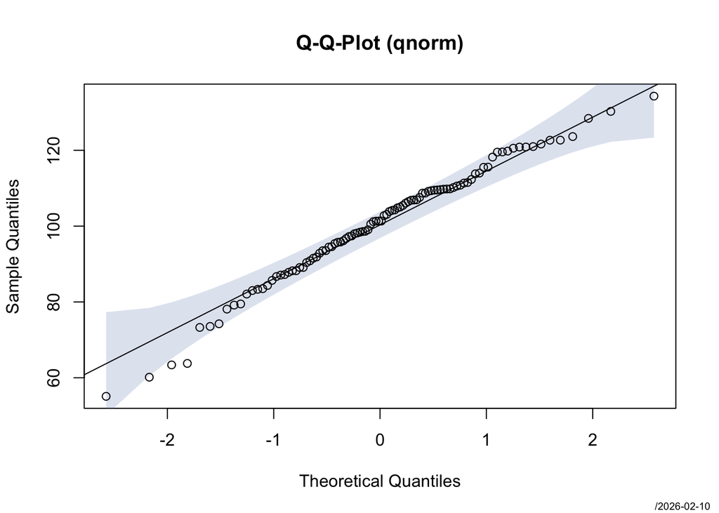

```r
suppressWarnings(library(DescTools))
PlotQQ(samp)
```

```r
#hist(samp)
```

Q-Q plot (квантильная диаграмма) строится путем построения точек с координатами, соответствующим их квантилям (теоретические квантилии против наблюдаемых в выборке).  
* если точки лежат на диагонали, все в порядке  
* если наблюдаются тяжелые “хвосты” по углам, то данные распределены ненормально (или данных очень мало)  
* лесенка – данные округлены или дискретные  
* змейка – skewed data  
* график также позволяет увидеть выбросы - единичные точки

Аналогично с использованием `ggplot`:

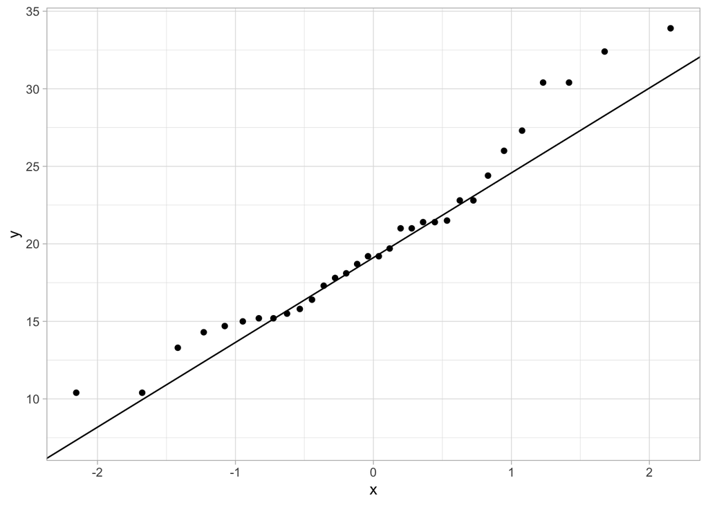

```r
ggplot(mtcars, aes(sample = mpg)) +
  stat_qq() +
  stat_qq_line() +
  theme_light()
```

### Упражнение 2

Данные из работы “Vowel duration and aspiration effects in Icelandic”, Stefano Coretta, University of York, 2016 [link](https://osf.io/6au2k/). В диссертации тестируется ряд гипотез:  
Voicing effect: vowels are longer than followed by voiced consonants;  
Aspiration effect: vowels followed by pre-aspirated (geminate) stops are shorter than vowels followed by unaspirated (geminate) stops.

Давайте проверим, есть ли статистически значимая разница в средних значениях переменной times в условиях roundness = “round” и “unrounded”? Есть ли статистически значимая разница между средними значениями vowel.dur в тех же условиях?

1. Сформулируйте нулевую и альтернативную гипотезы: $H_0: mean(....) = mean(....)$ $H_1: mean(....) \ne mean(....)$
2. Исследуйте данные с помощью боксплота, сформулируйте выводы после визуальной оценки.

```r
library("tidyverse")
icelandic <- read.csv("https://bit.ly/39Fr0gD")
```

3. Создайте два вектора, round_times и unrounded_times, сравните их длину.

```r
# round_times <- icelandic |>


# unrounded_times <- icelandic |>
```

4. Определитесь с типом t-теста, проведите его и интерпретируйте.
5. Сформулируйте вывод (не забудьте аргументировать их результатами теста).
6. Повторите анализ, чтобы ответить на второй вопрос (Есть ли статистически значимая разница между средними значениями vowel.dur в тех же условиях?)

p-value = 0.3359 = 33% [0,1] $\alpha = 5%$ p-value > 5% ==> не можем отвергнуть нулевую гипотезу

Согласно t-критерию Стьюдента (t = -0.9631, df = 589.36, p-value = 0.3359) нельзя отвергнуть нулевую гипотезу. Статистически значимой разницы между средними не найдено. Наши данные не дают возможности утверждать, что разница есть. Между долготой гласного, вероятно, нет разницы.

## Непараметрические аналоги t-теста

Если выборка не очень большая и взята из сильно ассиметричного распределения или выборка представляет собой порядковые данные, то можно воспользоваться непараметрическими альтернативами для t-теста.

Непараметрические тесты не имеют допущений о распределении, что делает их более универсальными. Большинство подобных тестов подразумевает превращение данных в ранги, т.е. внутри этих тестов происходит преобразование в ранговую шкалу. Такое преобразование может снизить статистическую мощность теста и привести к повышению вероятности ошибки второго рода.

### Тест Уилкоксона

Непараметрический аналог двустороннего *зависимого* t-теста называется **тестом Уилкоксона.** Функция для него называется `wilcox.test()`, и она имеет такой же синтаксис, как и `t.test()`.

```r
wilcox.test(diet1$pre.weight, diet1$weight6weeks, paired = TRUE)
```

```
##
##  Wilcoxon signed rank test with continuity correction
##
## data:  diet1$pre.weight and diet1$weight6weeks
## V = 299, p-value = 2.203e-05
## alternative hypothesis: true location shift is not equal to 0
```

> Cообщение *“Есть совпадающие значения: не могу высчитать точное p-значение”* означает, что в ваших данных есть повторяющиеся значения, поэтому расчет p-value в данном случае — это некоторая апроксимация. В большинстве случаев это сообщение можно игнорировать.

### Тест Манна-Уитни

Непараметрическим аналогом двустороннего *независимого* t-теста является **тест Манна-Уитни.** Для него тоже используется функция `wilcox.test()`, только с параметром по умолчанию `paired = FALSE`.

```r
wilcox.test(weight6weeks ~ Diet, data = diet12)
```

```
##
##  Wilcoxon rank sum test with continuity correction
##
## data:  weight6weeks by Diet
## W = 368, p-value = 0.4117
## alternative hypothesis: true location shift is not equal to 0
```

| Внутрииндивидуальный план | Межиндивидуальный план |
| --- | --- |
| Зависимый t-тест: | Независимый t-тест: |
| `t.test(..., paired = TRUE)` | `t.test(..., paired = FALSE)` |
| Тест Уилкоксона: | Тест Манна-Уитни: |
| `wilcox.test(..., paired = TRUE)` | `wilcox.test(..., paired = FALSE)` |

## Корреляция (Correlation)

Сначала - **ковариация** (co-variation). - положительная ковариация: чем *больше* одна переменная, тем *больше* другая переменная. - отрицательная ковариация: чем *больше* одна переменная, тем *меньше* другая.

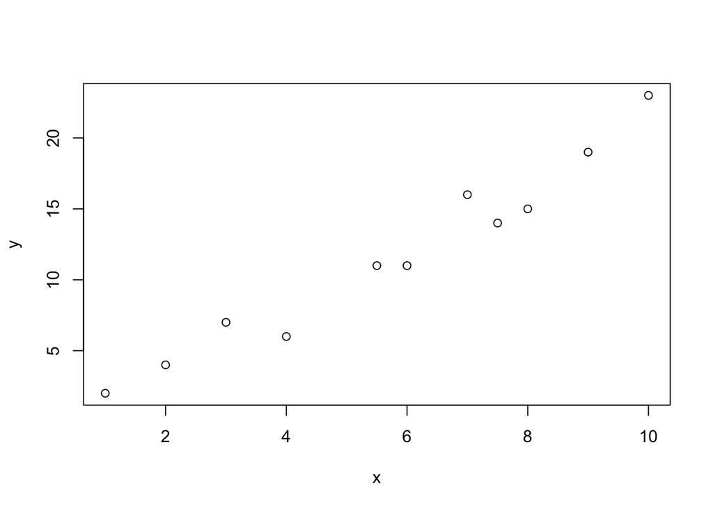

```r
x <- c(1, 2, 6, 8, 9, 7, 7.5, 10, 3, 4, 5.5)
y <- c(2, 4, 11, 15, 19, 16, 14, 23, 7, 6, 11)
plot(x, y)
```

- формула ковариации:
  $$\sigma_{xy} =
  cov(x, y) = \frac{\sum_{i = 1}^n(x_i - \overline{x})(y_i -
  \overline{y})}{n}$$
- Оценка ковариации по выборке:

$$\hat{\sigma}_{xy} = \frac{\sum_{i =
1}^n(x_i - \overline{x})(y_i - \overline{y})}{n-1}$$
Дисперсия - ковариация переменной самой с собой.

```r
cov(x, y)
```

```
## [1] 18.64091
```

```r
var(x, y) # функция дисперсии при двух переменных считает то же самое
```

```
## [1] 18.64091
```

Значение ковариации привязано к исходной шкале данных. Много или мало - трудно сказать.

Корреляция - как сама связь между переменными, так и способ ее измерить.

## Коэффициенты корреляции Пирсона и Спирмена/Кенделла

(Pearson’s coefficient vs Spearman’s and Kendall’s coefficients)

- Коэффициент Пирсона - для непрерывных данных
- Принимает значение от -1 (отрицательная корреляция) до 1 (положительная корреляция)
- Нормированная ковариация (ковариация, нормированная на стандартное отклонение обеих переменных)
- Можно понимать как среднее произведение z-scores
- условие для Пирсона – примерно нормальное распределение переменных
- Коэффициент Пирсона чувствителен к выбросам
- Коэффициент Спирмена/Кенделла - для шкальных или непрерывных данных (шкала Ликерта, доли и т.д.)
- условие для Спирмена – парные измерения (количество точек x и у совпадает)
- желательное условие для Спирмена/Кенделла – монотонная связь между переменными
- не ловит нелинейную связь

$$\rho_{xy} = \frac{\sigma_{xy}}{\sigma_x
\sigma_y} = \frac{\sum_{i = 1}^n(x_i - \overline{x})(y_i -
\overline{y})}{\sqrt{\sum_{i = 1}^n(x_i - \overline{x})^2}\sqrt{\sum_{i
= 1}^n(y_i - \overline{y})^2}} = \frac{1}{n}\sum_{i = 1}^n z_{x,i} z_{y,
i}$$

Оценка коэффициента корреляции Пирсона по выборке:
$$r_{xy} = \frac{\hat{\sigma}_{xy}}{\hat{\sigma}_x
\hat{\sigma}_y} = \frac{\sum_{i = 1}^n(x_i - \overline{x})(y_i -
\overline{y})}{\sqrt{\sum_{i = 1}^n(x_i - \overline{x})^2}\sqrt{\sum_{i
= 1}^n(y_i - \overline{y})^2}} = \frac{1}{n - 1}\sum_{i = 1}^n z_{x,i}
z_{y, i}$$

```r
# Pearson's correlation
cor(x, y)
```

```
## [1] 0.9773737
```

Корреляция положительная и сильная (почти равна 1).

Статистическая значимость корреляции (например, при $\alpha$ = 0.05).

- Какую нулевую гипотезу мы тестируем?

```r
# Pearson's coefficient
cor.test(x, y)
```

```
##
##  Pearson's product-moment correlation
##
## data:  x and y
## t = 13.862, df = 9, p-value = 2.234e-07
## alternative hypothesis: true correlation is not equal to 0
## 95 percent confidence interval:
##  0.9124984 0.9942928
## sample estimates:
##       cor
## 0.9773737
```

$H_o$ - отсутствие корреляции в генеральной совокупности
$$H_0: (\rho_{xy} =
0)$$
Если переменных не две, а больше?

```r
#install.packages("Stat2Data")
library(Stat2Data)
library(psych)
data(Backpack)
Backpack |>
  mutate(backpack_kg = 0.45359237 * BackpackWeight,
         body_kg = 0.45359237 * BodyWeight) |>
  select(body_kg, backpack_kg, Units, Year) |>
#cor()
#  psych::corr.test()
#  psych::corr.test(adjust = "bonferroni")
  psych::corr.test(adjust = "BH")
```

```
## Call:psych::corr.test(x = select(mutate(Backpack, backpack_kg = 0.45359237 *
##     BackpackWeight, body_kg = 0.45359237 * BodyWeight), body_kg,
##     backpack_kg, Units, Year), adjust = "BH")
## Correlation matrix
##             body_kg backpack_kg Units  Year
## body_kg        1.00        0.19 -0.24 -0.09
## backpack_kg    0.19        1.00  0.09  0.06
## Units         -0.24        0.09  1.00 -0.03
## Year          -0.09        0.06 -0.03  1.00
## Sample Size
## [1] 100
## Probability values (Entries above the diagonal are adjusted for multiple tests.)
##             body_kg backpack_kg Units Year
## body_kg        0.00        0.18  0.11 0.54
## backpack_kg    0.06        0.00  0.54 0.68
## Units          0.02        0.35  0.00 0.77
## Year           0.36        0.57  0.77 0.00
##
##  To see confidence intervals of the correlations, print with the short=FALSE option
```

#### Проблема множественных сравнений

- поправка Бонферрони (Bonferroni correction)
- умножение p-value на количество гипотез
- поправка Холма или поправка Холма-Бонферрони (Holm-Bonferroni correction)
- поправка Бенджамини-Хохберга (BH, Benjamini-Hochberg correction) как контроль False Discovery Rate (FDR, средняя доля ложных отклонений при заданной $\alpha$, например, доля FDR меньше 5%)

```r
library(corrplot)
cor(mtcars)
```

```
##             mpg        cyl       disp         hp        drat         wt
## mpg   1.0000000 -0.8521620 -0.8475514 -0.7761684  0.68117191 -0.8676594
## cyl  -0.8521620  1.0000000  0.9020329  0.8324475 -0.69993811  0.7824958
## disp -0.8475514  0.9020329  1.0000000  0.7909486 -0.71021393  0.8879799
## hp   -0.7761684  0.8324475  0.7909486  1.0000000 -0.44875912  0.6587479
## drat  0.6811719 -0.6999381 -0.7102139 -0.4487591  1.00000000 -0.7124406
## wt   -0.8676594  0.7824958  0.8879799  0.6587479 -0.71244065  1.0000000
## qsec  0.4186840 -0.5912421 -0.4336979 -0.7082234  0.09120476 -0.1747159
## vs    0.6640389 -0.8108118 -0.7104159 -0.7230967  0.44027846 -0.5549157
## am    0.5998324 -0.5226070 -0.5912270 -0.2432043  0.71271113 -0.6924953
## gear  0.4802848 -0.4926866 -0.5555692 -0.1257043  0.69961013 -0.5832870
## carb -0.5509251  0.5269883  0.3949769  0.7498125 -0.09078980  0.4276059
##             qsec         vs          am       gear        carb
## mpg   0.41868403  0.6640389  0.59983243  0.4802848 -0.55092507
## cyl  -0.59124207 -0.8108118 -0.52260705 -0.4926866  0.52698829
## disp -0.43369788 -0.7104159 -0.59122704 -0.5555692  0.39497686
## hp   -0.70822339 -0.7230967 -0.24320426 -0.1257043  0.74981247
## drat  0.09120476  0.4402785  0.71271113  0.6996101 -0.09078980
## wt   -0.17471588 -0.5549157 -0.69249526 -0.5832870  0.42760594
## qsec  1.00000000  0.7445354 -0.22986086 -0.2126822 -0.65624923
## vs    0.74453544  1.0000000  0.16834512  0.2060233 -0.56960714
## am   -0.22986086  0.1683451  1.00000000  0.7940588  0.05753435
## gear -0.21268223  0.2060233  0.79405876  1.0000000  0.27407284
## carb -0.65624923 -0.5696071  0.05753435  0.2740728  1.00000000
```

Основная функция пакета `{corrplot}` – функция `corrplot()`. Давайте теперь попробуем ее применить на нашей матрице корреляций.

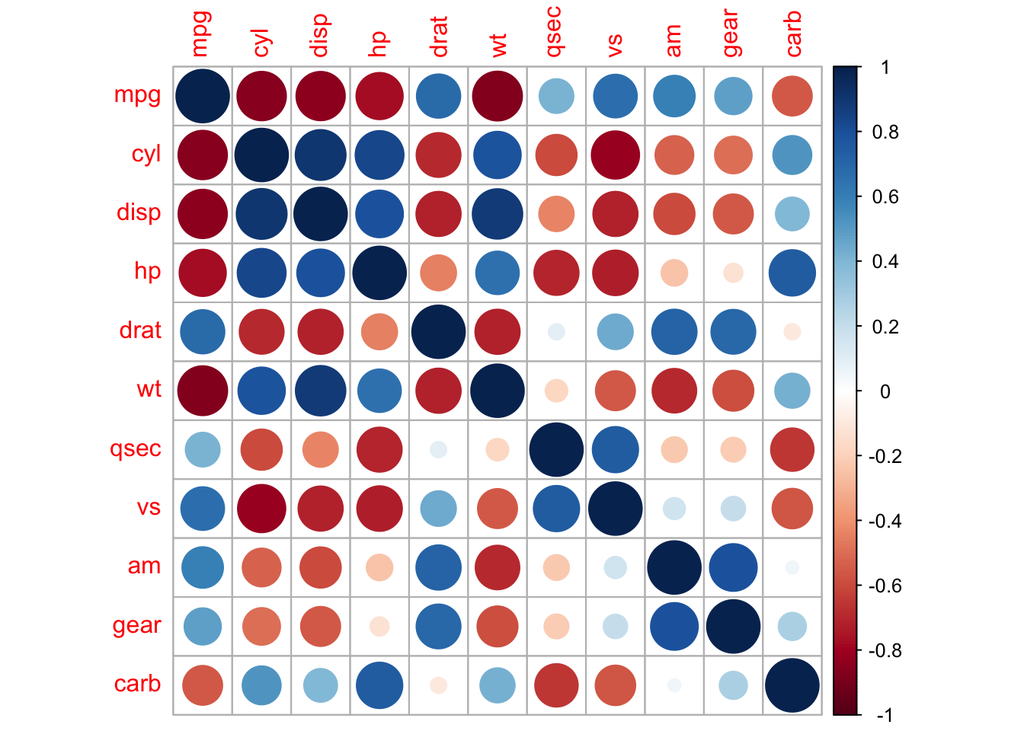

```r
corrplot(cor(mtcars))
```

По умолчанию значение корреляций кодируется цветом и размером круга. У функции `corrplot()` есть множество параметров, позволяющих довольно тонко настраивать хитмэп корреляций. Например, можнокодировать только цветом, а переменные сгруппировать на основе кластеризации.

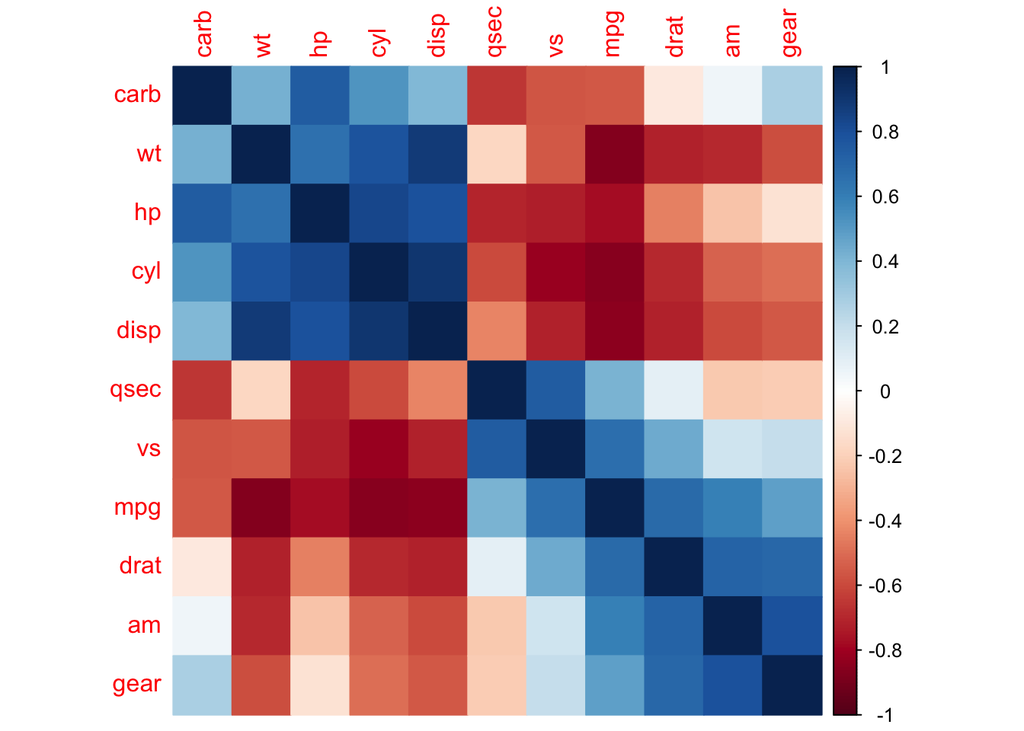

```r
corrplot(cor(mtcars), method = "color", order = "hclust")
```

Или так: [source](https://www.r-bloggers.com/spearman-correlation-heat-map-with-correlation-coefficients-and-significance-levels-in-r/)

```r
suppressMessages(library(Hmisc))
suppressMessages(library(reshape2))
cormatrix <- rcorr(as.matrix(mtcars), type='spearman')
cormatrix
```

```
##        mpg   cyl  disp    hp  drat    wt  qsec    vs    am  gear  carb
## mpg   1.00 -0.91 -0.91 -0.89  0.65 -0.89  0.47  0.71  0.56  0.54 -0.66
## cyl  -0.91  1.00  0.93  0.90 -0.68  0.86 -0.57 -0.81 -0.52 -0.56  0.58
## disp -0.91  0.93  1.00  0.85 -0.68  0.90 -0.46 -0.72 -0.62 -0.59  0.54
## hp   -0.89  0.90  0.85  1.00 -0.52  0.77 -0.67 -0.75 -0.36 -0.33  0.73
## drat  0.65 -0.68 -0.68 -0.52  1.00 -0.75  0.09  0.45  0.69  0.74 -0.13
## wt   -0.89  0.86  0.90  0.77 -0.75  1.00 -0.23 -0.59 -0.74 -0.68  0.50
## qsec  0.47 -0.57 -0.46 -0.67  0.09 -0.23  1.00  0.79 -0.20 -0.15 -0.66
## vs    0.71 -0.81 -0.72 -0.75  0.45 -0.59  0.79  1.00  0.17  0.28 -0.63
## am    0.56 -0.52 -0.62 -0.36  0.69 -0.74 -0.20  0.17  1.00  0.81 -0.06
## gear  0.54 -0.56 -0.59 -0.33  0.74 -0.68 -0.15  0.28  0.81  1.00  0.11
## carb -0.66  0.58  0.54  0.73 -0.13  0.50 -0.66 -0.63 -0.06  0.11  1.00
##
## n= 32
##
##
## P
##      mpg    cyl    disp   hp     drat   wt     qsec   vs     am     gear
## mpg         0.0000 0.0000 0.0000 0.0000 0.0000 0.0071 0.0000 0.0008 0.0013
## cyl  0.0000        0.0000 0.0000 0.0000 0.0000 0.0006 0.0000 0.0022 0.0008
## disp 0.0000 0.0000        0.0000 0.0000 0.0000 0.0081 0.0000 0.0001 0.0003
## hp   0.0000 0.0000 0.0000        0.0023 0.0000 0.0000 0.0000 0.0416 0.0639
## drat 0.0000 0.0000 0.0000 0.0023        0.0000 0.6170 0.0102 0.0000 0.0000
## wt   0.0000 0.0000 0.0000 0.0000 0.0000        0.2148 0.0004 0.0000 0.0000
## qsec 0.0071 0.0006 0.0081 0.0000 0.6170 0.2148        0.0000 0.2644 0.4182
## vs   0.0000 0.0000 0.0000 0.0000 0.0102 0.0004 0.0000        0.3570 0.1170
## am   0.0008 0.0022 0.0001 0.0416 0.0000 0.0000 0.2644 0.3570        0.0000
## gear 0.0013 0.0008 0.0003 0.0639 0.0000 0.0000 0.4182 0.1170 0.0000
## carb 0.0000 0.0005 0.0014 0.0000 0.4947 0.0036 0.0000 0.0000 0.7264 0.5312
##      carb
## mpg  0.0000
## cyl  0.0005
## disp 0.0014
## hp   0.0000
## drat 0.4947
## wt   0.0036
## qsec 0.0000
## vs   0.0000
## am   0.7264
## gear 0.5312
## carb
```

```r
str(cormatrix)
```

```
## List of 4
##  $ r   : num [1:11, 1:11] 1 -0.911 -0.909 -0.895 0.651 ...
##   ..- attr(*, "dimnames")=List of 2
##   .. ..$ : chr [1:11] "mpg" "cyl" "disp" "hp" ...
##   .. ..$ : chr [1:11] "mpg" "cyl" "disp" "hp" ...
##  $ n   : int [1:11, 1:11] 32 32 32 32 32 32 32 32 32 32 ...
##   ..- attr(*, "dimnames")=List of 2
##   .. ..$ : chr [1:11] "mpg" "cyl" "disp" "hp" ...
##   .. ..$ : chr [1:11] "mpg" "cyl" "disp" "hp" ...
##  $ P   : num [1:11, 1:11] NA 4.69e-13 6.37e-13 5.09e-12 5.38e-05 ...
##   ..- attr(*, "dimnames")=List of 2
##   .. ..$ : chr [1:11] "mpg" "cyl" "disp" "hp" ...
##   .. ..$ : chr [1:11] "mpg" "cyl" "disp" "hp" ...
##  $ type: chr "spearman"
##  - attr(*, "class")= chr "rcorr"
```

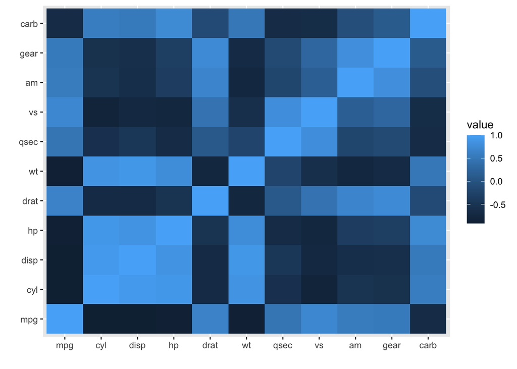

```r
cordata <- melt(cormatrix$r)
ggplot(cordata, aes(x=Var1, y=Var2, fill=value)) +
  geom_tile() + xlab("") + ylab("")
```

### Коэффициенты корреляции Спирмена и Кендалла

Коэффициент корреляции Спирмена использует формулу Пирсона, но вместо абсолютных значений используются (частотные) ранги значений.

```r
x = c(277,169,157,139,108,213,232,229,114,232,161,149,128)
y = c(256,118,137,144,146,221,184,188,97,231,114,187,230)
rx = rank(x)
# rx = {13, 8, 6, 4, 1, 9, 11.5, 10,  2, 11.5,  7,  5,  3}
ry = rank(y)
mx = mean(rx)
my = mean(ry)
sum((rx-mx)*(ry-my))/sqrt(sum((rx-mx)^2)*sum((ry-my)^2))
```

```
## [1] 0.5144434
```

```r
# 0.5144434
cor(rx,ry)
```

```
## [1] 0.5144434
```

```r
# 0.5144434

cor.test(x, y, method = 'spearman')
```

```
##
##  Spearman's rank correlation rho
##
## data:  x and y
## S = 176.74, p-value = 0.07206
## alternative hypothesis: true rho is not equal to 0
## sample estimates:
##       rho
## 0.5144434
```

```r
cor.test(x, y, method = 'kendall')
```

```
## Warning in cor.test.default(x, y, method = "kendall"): Cannot compute exact
## p-value with ties
```

```
##
##  Kendall's rank correlation tau
##
## data:  x and y
## z = 1.6503, p-value = 0.09888
## alternative hypothesis: true tau is not equal to 0
## sample estimates:
##       tau
## 0.3483943
```

Если в данных есть совпадающие значения, тест Спирмена выдаст предупреждение “Cannot compute exact p-values with ties”. В этом случае можно задать аргумент `exact=FALSE`, чтобы не видеть предупреждения, но проблемы это не решит. Особенно если размер выборки небольшой.  
Первый путь - задать для совпадающих значений промежуточные ранги (написать функцию или указать конкретный вектор). Другой путь – использовать тест Кендалла с поправкой на ties:

$$Kendall's \tau_b = (P - Q) / ( (P
+ Q + Y_0)*(P + Q + X_0) )^{0.5}$$

, где  
$P$: количество согласующихся пар (ранги в паре либо оба увеличиваются, либо оба убывают)  
$Q$: количество несогласующихся пар  
$X_0$: количество пар x с неповторяющимися значениями (not tied on x)  
$Y_0$: количество пар y с неповторяющимися значениями (not tied on y)

```r
cor.test(x,y, method = 'spearman')
```

```
## Warning in cor.test.default(x, y, method = "spearman"): Cannot compute exact
## p-value with ties
```

```
##
##  Spearman's rank correlation rho
##
## data:  x and y
## S = 176.74, p-value = 0.07206
## alternative hypothesis: true rho is not equal to 0
## sample estimates:
##       rho
## 0.5144434
```

```r
cor.test(rx,ry) # Pearson on ranks is Spearman
```

```
##
##  Pearson's product-moment correlation
##
## data:  rx and ry
## t = 1.9897, df = 11, p-value = 0.07206
## alternative hypothesis: true correlation is not equal to 0
## 95 percent confidence interval:
##  -0.05099705  0.83012823
## sample estimates:
##       cor
## 0.5144434
```

```r
rx = c(13, 8, 6, 4, 1, 9, 11.45, 10,  2, 11.5,  7,  5,  3) # ranks corrected manually
cor.test(rx,ry) # Pearson on non-averaged (non-tied) ranks is Spearman-no-ties
```

```
##
##  Pearson's product-moment correlation
##
## data:  rx and ry
## t = 1.993, df = 11, p-value = 0.07165
## alternative hypothesis: true correlation is not equal to 0
## 95 percent confidence interval:
##  -0.05013446  0.83039689
## sample estimates:
##      cor
## 0.515079
```

Итак, методы Спирмена и Кендалла почти во всех случаях взаимозаменимы, но коэффициент Спирмена будет сильнее штрафовать сильную несогласованность в рангах (см. сумму квадратов в знаменателе), в то время как коэффицент Кендалла оценивает их более линейно.

### Как отчитаться о проведенном тесте

```
С целью определить связь между <переменной А> и <переменной Б> был проведен корреляционный анализ Пирсона/Спирмена/Кендалла. Найдена статистически значимая сильная положительная корреляция между <переменной А> и <переменной Б> (r/ρ/τ = .535, p = .003, df=8, n=10).
```

### Упражнение 3

Для работы возьмите датасет по рассказам А. П. Чехова (`chekhov.csv`, [link](https://raw.githubusercontent.com/LingData2019/LingData2020/master/data/chekhov.csv)).

Переменные: * `n_words`: количество слов в рассказе * `n_unique`: количество уникальных слов в рассказе

1. Каков ваш прогноз, есть ли линейная связь между количеством слов (= длиной текста) и количеством уникальных слов?
2. С помощью `ggplot` постройте график рассеяния для этих переменных и проверьте вашу интуицию. Используйте прозрачность alpha для лучшего понимания картины. Интерпретируйте данные на графике.
3. Используйте подходящий статистический критерий для проверки гипотезы о связи между значениями переменных `n_words` и `n_unique`: сформулируйте нулевую гипотезу, протестируйте ее и сформулируйте выводы.

```r
chekhov <- read_csv("https://raw.githubusercontent.com/LingData2019/LingData2020/master/data/chekhov.csv") |>
  dplyr::select(n_words, n_unique)
```

```
## ──────────────────────────────────────────────────────── Delimiter: "," chr
## (1): title dbl (3): ...1, n_words, n_unique
```

### Misc

Графическая интерпретация коэффициента корреляции Пирсона – соотношение точек в закрашенных и незакрашенных областях.

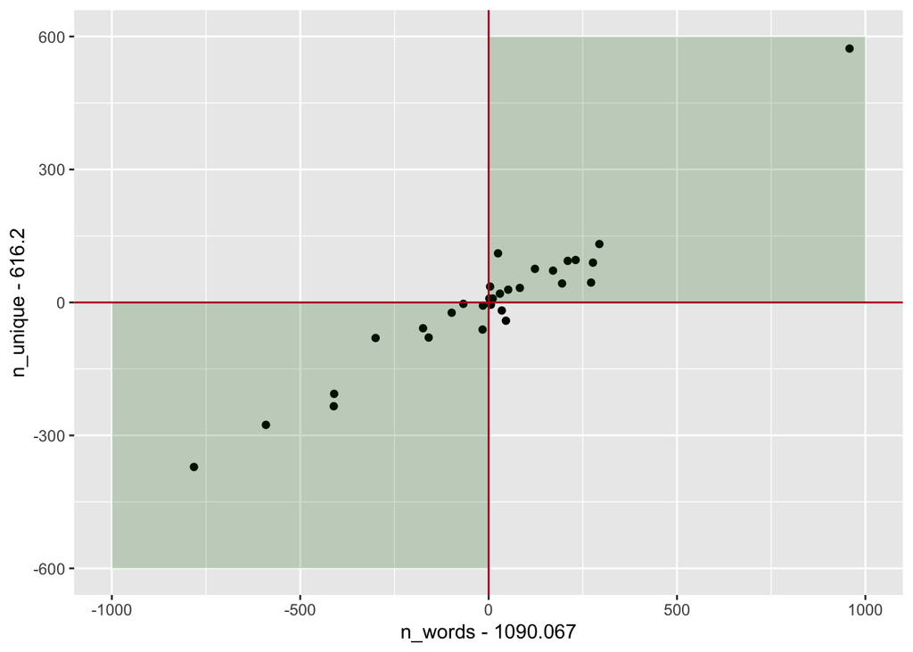

```r
ggplot(chekhov, aes(n_words-1090.067, n_unique-616.200)) +
  geom_point() +
  geom_vline(xintercept = 0, colour="#BA1825") +
  geom_hline(yintercept = 0, colour="#BA1825") +
  xlim(-1000, 1000) +
  ylim(-600,600) +
  annotate('rect', xmin=1, xmax=1000, ymin=1, ymax=600, alpha=.2, fill='darkgreen') +
  annotate('rect', xmin=-1000, xmax=-1, ymin=-600, ymax=-1, alpha=.2, fill='darkgreen')
```

```r
cor.test(chekhov$n_words,chekhov$n_unique)
```

```
##
##  Pearson's product-moment correlation
##
## data:  chekhov$n_words and chekhov$n_unique
## t = 19.262, df = 28, p-value < 2.2e-16
## alternative hypothesis: true correlation is not equal to 0
## 95 percent confidence interval:
##  0.9255371 0.9830385
## sample estimates:
##       cor
## 0.9642758
```

Пример нелинейной зависимости и непараметрический корреляционный анализ:

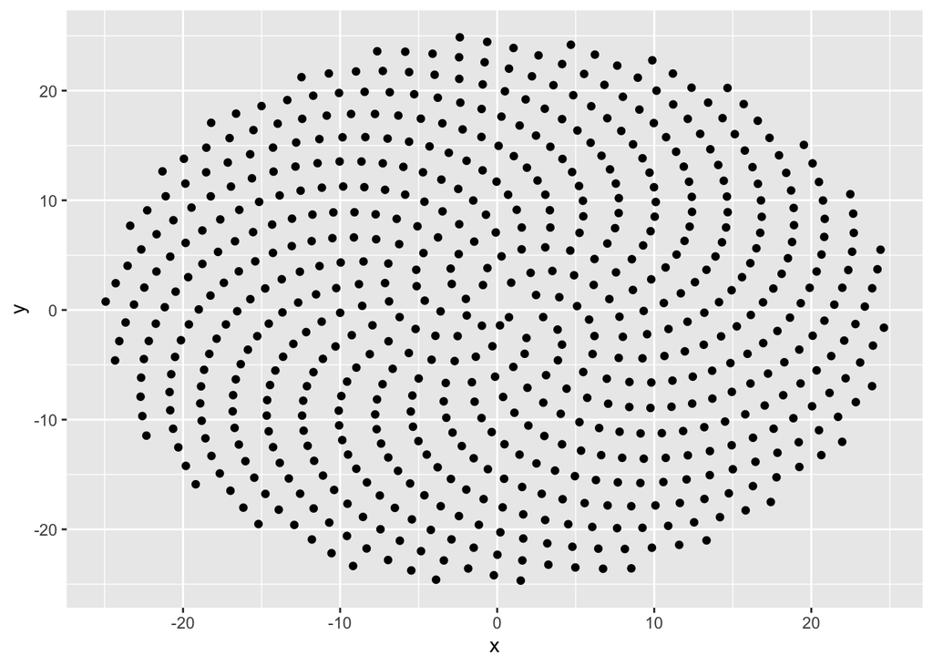

```r
golden.ratio = (sqrt(5) + 1)/2
fibonacci.angle=360/(golden.ratio^2)
c=1
num_points=630
x=rep(0,num_points)
y=rep(0,num_points)

for (n in 1:num_points) {
    r=c*sqrt(n)
    theta=fibonacci.angle*(n)
    x[n]=r*cos(theta)
    y[n]=r*sin(theta)
}
data.frame(x,y) |>
ggplot(aes(x, y)) +
  geom_point()
```

```r
cor.test(x, y, method = 'spearman')
```

```
##
##  Spearman's rank correlation rho
##
## data:  x and y
## S = 41585740, p-value = 0.9575
## alternative hypothesis: true rho is not equal to 0
## sample estimates:
##         rho
## 0.002127325
```

```r
cor.test(x, y, method = 'kendall')
```

```
##
##  Kendall's rank correlation tau
##
## data:  x and y
## z = 0.058175, p-value = 0.9536
## alternative hypothesis: true tau is not equal to 0
## sample estimates:
##         tau
## 0.001549449
```